# **Data Mining Analysis:** **Comparative Classification Modeling, Clustering and Outlier Detection**

Ibaale Eric Student No: 2300708288 Reg No: 23/U/08288/PS Course Unit: Data Mining

2026-06-15

# 1 Introduction

This report presents a comprehensive data mining analysis covering two major areas: supervised classification modeling and unsupervised clustering with outlier detection.

**Part 1** applies five supervised machine learning classification algorithms to the Adult Income dataset derived from the 1994 U.S. Census database. The primary objective is to predict whether an individual earns more than $50,000 per year based on demographic and socioeconomic characteristics. The workflow covers data loading, quality assessment, exploratory data analysis, model training, evaluation, and comparative assessment.

The five classification models evaluated are:

1. **Decision Tree**: Rule-based, tree-structured classifier
2. **Naïve Bayes**: Probabilistic classifier based on Bayes’ theorem
3. **Logistic Regression**: Parametric linear classification model
4. **K-Nearest Neighbors (KNN)**: Distance-based non-parametric classifier
5. **Artificial Neural Network (ANN)**: Multi-layer feedforward neural network

**Part 2** applies K-Means clustering, agglomerative hierarchical clustering, and three outlier detection methods to the Iris dataset. The clustering analysis examines how well unsupervised methods recover the known species groupings, while the outlier analysis compares the IQR method, Local Outlier Factor (LOF), and Isolation Forest.

All analyses are reproducible using `set.seed(123)`.

# 2 Data Loading and Preprocessing

## 2.1 Loading Required Libraries

```r
# Core data manipulation and visualisation
library(tidyverse)
library(reshape2)
library(ggplot2)

# Table formatting
library(knitr)
library(kableExtra)

# Classification models
library(rpart)         # Decision Tree
library(rpart.plot)    # Decision Tree visualisation
library(e1071)         # Naive Bayes
library(class)         # KNN
library(nnet)          # Artificial Neural Network (ANN)

# Model evaluation and ROC analysis
library(caret)
library(pROC)
```

## 2.2 Loading the Dataset

```r
setwd("E:/DESKTOP/YR3/sem2/Notes/data_mining/Adult_dataset_scripts")

adult <- read.csv("adult.data", header = FALSE, strip.white = TRUE)

colnames(adult) <- c(
  "age", "workclass", "fnlwgt", "education", "education_num",
  "marital_status", "occupation", "relationship", "race", "sex",
  "capital_gain", "capital_loss", "hours_per_week", "native_country", "income"
)
```

The dataset was imported into R by setting the working directory to the location where the dataset files were stored. The `adult.data` file was then read into R using the `read.csv()` function and stored in an object called `adult`. Since the dataset did not contain column headers, appropriate variable names were manually assigned using the `colnames()` function. These included `age`, `workclass`, `education`, `education_num`, `marital_status`, `occupation`, `relationship`, `race`, `sex`, `capital_gain`, `capital_loss`, `hours_per_week`, `native_country`, and the target variable `income`.

```r
str(adult)     # Structure of the dataset
```

```
## 'data.frame':    32561 obs. of  15 variables:
##  $ age           : int  39 50 38 53 28 37 49 52 31 42 ...
##  $ workclass     : chr  "State-gov" "Self-emp-not-inc" "Private" "Private" ...
##  $ fnlwgt        : int  77516 83311 215646 234721 338409 284582 160187 209642 45781 159449 ...
##  $ education     : chr  "Bachelors" "Bachelors" "HS-grad" "11th" ...
##  $ education_num : int  13 13 9 7 13 14 5 9 14 13 ...
##  $ marital_status: chr  "Never-married" "Married-civ-spouse" "Divorced" "Married-civ-spouse" ...
##  $ occupation    : chr  "Adm-clerical" "Exec-managerial" "Handlers-cleaners" "Handlers-cleaners" ...
##  $ relationship  : chr  "Not-in-family" "Husband" "Not-in-family" "Husband" ...
##  $ race          : chr  "White" "White" "White" "Black" ...
##  $ sex           : chr  "Male" "Male" "Male" "Male" ...
##  $ capital_gain  : int  2174 0 0 0 0 0 0 0 14084 5178 ...
##  $ capital_loss  : int  0 0 0 0 0 0 0 0 0 0 ...
##  $ hours_per_week: int  40 13 40 40 40 40 16 45 50 40 ...
##  $ native_country: chr  "United-States" "United-States" "United-States" "United-States" ...
##  $ income        : chr  "<=50K" "<=50K" "<=50K" "<=50K" ...
```

```r
summary(adult) # Summary statistics
```

```
##       age         workclass             fnlwgt         education
##  Min.   :17.00   Length:32561       Min.   :  12285   Length:32561
##  1st Qu.:28.00   Class :character   1st Qu.: 117827   Class :character
##  Median :37.00   Mode  :character   Median : 178356   Mode  :character
##  Mean   :38.58                      Mean   : 189778
##  3rd Qu.:48.00                      3rd Qu.: 237051
##  Max.   :90.00                      Max.   :1484705
##  education_num   marital_status      occupation        relationship
##  Min.   : 1.00   Length:32561       Length:32561       Length:32561
##  1st Qu.: 9.00   Class :character   Class :character   Class :character
##  Median :10.00   Mode  :character   Mode  :character   Mode  :character
##  Mean   :10.08
##  3rd Qu.:12.00
##  Max.   :16.00
##      race               sex             capital_gain    capital_loss
##  Length:32561       Length:32561       Min.   :    0   Min.   :   0.0
##  Class :character   Class :character   1st Qu.:    0   1st Qu.:   0.0
##  Mode  :character   Mode  :character   Median :    0   Median :   0.0
##                                        Mean   : 1078   Mean   :  87.3
##                                        3rd Qu.:    0   3rd Qu.:   0.0
##                                        Max.   :99999   Max.   :4356.0
##  hours_per_week  native_country        income
##  Min.   : 1.00   Length:32561       Length:32561
##  1st Qu.:40.00   Class :character   Class :character
##  Median :40.00   Mode  :character   Mode  :character
##  Mean   :40.44
##  3rd Qu.:45.00
##  Max.   :99.00
```

The structure and summary of the dataset were first examined to understand the variable types and general distribution of the data.

## 2.3 Data Quality Assessment

### 2.3.1 Missing Values

```r
# Count missing values encoded as "?"
sum(adult == "?")
```

```
## [1] 4262
```

```r
# Replace "?" placeholders with NA
adult[adult == "?"] <- NA

# Count missing values per column after replacement
colSums(is.na(adult))
```

```
##            age      workclass         fnlwgt      education  education_num
##              0           1836              0              0              0
## marital_status     occupation   relationship           race            sex
##              0           1843              0              0              0
##   capital_gain   capital_loss hours_per_week native_country         income
##              0              0              0            583              0
```

Missing values in the dataset were initially represented by the symbol `"?"`, so these were identified and replaced with `NA` to ensure proper handling in R. The total number of missing values per variable was then calculated. The results showed that missing values were present mainly in `workclass` (1,836), `occupation` (1,843), and `native_country` (583), while all other variables had no missing values.

### 2.3.2 Duplicate Values

```r
sum(duplicated(adult))      # Total number of duplicate entries
```

```
## [1] 24
```

```r
adult[duplicated(adult), ]  # View all duplicate rows
```

```
##       age        workclass fnlwgt    education education_num     marital_status
## 4882   25          Private 308144    Bachelors            13      Never-married
## 5105   90          Private  52386 Some-college            10      Never-married
## 9172   21          Private 250051 Some-college            10      Never-married
## 11632  20          Private 107658 Some-college            10      Never-married
## 13085  25          Private 195994      1st-4th             2      Never-married
## 15060  21          Private 243368    Preschool             1      Never-married
## 17041  46          Private 173243      HS-grad             9 Married-civ-spouse
## 18556  30          Private 144593      HS-grad             9      Never-married
## 18699  19          Private  97261      HS-grad             9      Never-married
## 21319  19          Private 138153 Some-college            10      Never-married
## 21491  19          Private 146679 Some-college            10      Never-married
## 21876  49          Private  31267      7th-8th             4 Married-civ-spouse
## 22301  25          Private 195994      1st-4th             2      Never-married
## 22368  44          Private 367749    Bachelors            13      Never-married
```

[output cut: 60 more lines]

The dataset contained a total of 24 duplicate observations.

### 2.3.3 Potential Outliers

```r
# Identifying outliers in all numeric columns using the IQR method
lapply(adult[sapply(adult, is.numeric)], function(x)
  boxplot.stats(x)$out)
```

```
## $age
##   [1] 79 90 80 81 90 88 90 90 80 90 81 82 79 81 80 83 90 90 79 81 90 90 80 90 90
##  [26] 79 79 84 90 80 90 81 83 84 81 79 85 82 79 80 90 90 90 84 80 90 90 79 84 90
##  [51] 79 90 90 90 82 81 90 84 79 81 82 81 80 90 80 84 82 79 90 84 90 83 79 81 80
##  [76] 79 80 79 80 90 90 80 90 90 81 83 82 90 90 81 80 80 90 79 80 82 85 80 79 90
## [101] 81 79 80 79 81 82 88 90 82 88 84 83 79 86 90 90 82 83 81 79 90 80 81 79 84
## [126] 84 79 90 80 81 81 81 90 87 90 80 80 82 90 90 85 82 81
##
## $fnlwgt
##   [1]  544091  507875  446839  432376  494223  428030  483777  633742  523910
##  [10]  635913  538583  477983  425161  860348  423158  481060  416103  445382
##  [19] 1033222  426017  543162  433665  462440  556660  430828  475028  420537
##  [28]  680390  499233  543028  465507  526968  767403  431192  520586  445824
##  [37]  416745  444304  441454  421132  795830  419721  509350  467108  444554
##  [46]  449257  441620  563883  431745  436006  473040  910398  451940  428350
```

[output cut: 857 more lines]

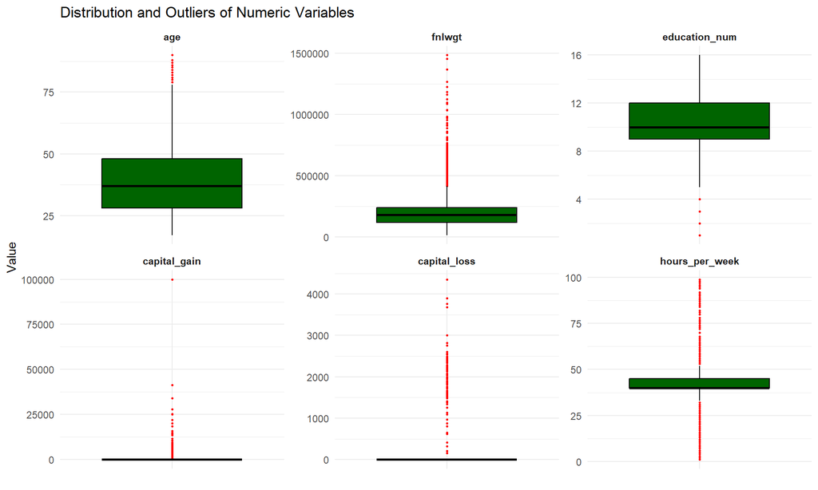

```r
# Visualising outliers using boxplots
num_data <- adult[sapply(adult, is.numeric)]
melted   <- melt(num_data, measure.vars = colnames(num_data))

ggplot(melted, aes(x = variable, y = value)) +
  geom_boxplot(fill = "darkgreen", color = "black",
               outlier.colour = "red", outlier.size = 0.5) +
  facet_wrap(~variable, scales = "free") +
  theme_minimal() +
  theme(axis.text.x = element_blank(),
        strip.text  = element_text(face = "bold")) +
  labs(title = "Distribution and Outliers of Numeric Variables",
       x     = "",
       y     = "Value")
```

Potential outliers were identified in several numeric variables using boxplots and the interquartile range (IQR) method. Very high values were observed in the `capital_gain` and `hours_per_week` variables. However, these values represent valid observations rather than data entry errors. Since decision tree models are generally robust to outliers, and to maintain consistency across all five models evaluated in this report, all observations were retained in the dataset.

## 2.4 Data Preprocessing

```r
# Remove rows with missing values and duplicate observations
adult <- na.omit(adult)
adult <- distinct(adult)

# Encode all character variables as factors
adult <- data.frame(lapply(adult, function(x) {
  if (is.character(x)) as.factor(x) else x
}))

# Confirm final dimensions
dim(adult)
levels(adult$income)
```

Missing values (now encoded as `NA`) were removed using `na.omit()`, and duplicate observations were dropped using `distinct()`. Categorical variables were then encoded as factors to ensure they were correctly interpreted by all classification models. The dataset contains demographic and employment features for individuals, with `income` as the binary target variable (`<=50K` vs `>50K`).

# 3 Exploratory Data Analysis

## 3.1 Distribution of the Target Variable

```r
table(adult$income) %>%
  kable(col.names = c("Income Level", "Frequency"),
        caption   = "Distribution of Income Levels",
        align     = "c") %>%
  kable_classic(html_font = "Cambria") %>%
  row_spec(0, bold = TRUE, color = "white", background = "#2c3e50") %>%
  kable_styling(latex_options = c("scale_down", "hold_position"),
                position = "center")
```

Distribution of Income Levels

| Income Level | Frequency |
| --- | --- |
| <=50K | 22633 |
| >50K | 7506 |

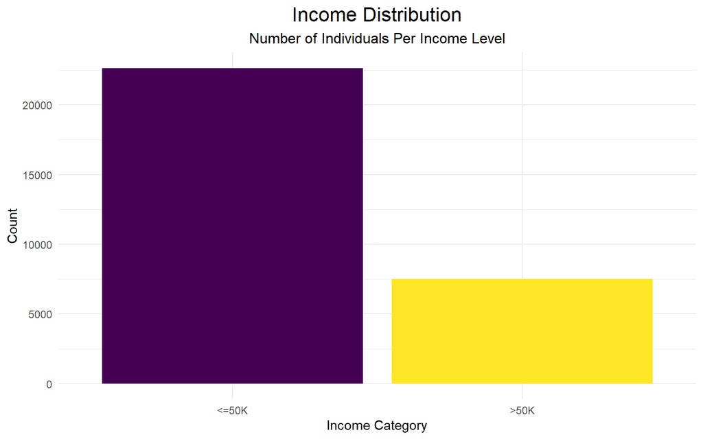

```r
ggplot(adult, aes(x = income, fill = income)) +
  geom_bar() +
  scale_fill_viridis_d() +
  labs(title    = "Income Distribution",
       subtitle = "Number of Individuals Per Income Level",
       x        = "Income Category",
       y        = "Count") +
  theme_minimal() +
  theme(legend.position = "none",
        plot.title      = element_text(hjust = 0.5, size = 16),
        plot.subtitle   = element_text(hjust = 0.5, size = 12))
```

## 3.2 Education vs Income

```r
edu_income_table <- table(adult$education, adult$income)

edu_income_table %>%
  kable(caption   = "Education Level vs Income Category",
        col.names = c("<=50K", ">50K"),
        align     = "c") %>%
  kable_classic(html_font = "Cambria") %>%
  row_spec(0, bold = TRUE, color = "white", background = "#2c3e50") %>%
  add_header_above(c("Education Level" = 1, "Income Categories" = 2),
                   bold = TRUE, color = "white", background = "#2c3e50") %>%
  kable_styling(latex_options = c("scale_down", "hold_position"),
                position = "center")
```

Education Level vs Income Category

| Education Level | Income Categories <=50K | Income Categories >50K |
| --- | --- | --- |
| 10th | 761 | 59 |
| 11th | 989 | 59 |
| 12th | 348 | 29 |
| 1st-4th | 143 | 6 |
| 5th-6th | 275 | 12 |
| 7th-8th | 521 | 35 |
| 9th | 430 | 25 |
| Assoc-acdm | 752 | 256 |
| Assoc-voc | 963 | 344 |
| Bachelors | 2916 | 2126 |
| Doctorate | 95 | 280 |
| HS-grad | 8218 | 1616 |
| Masters | 708 | 918 |
| Preschool | 44 | 0 |
| Prof-school | 136 | 406 |
| Some-college | 5334 | 1335 |

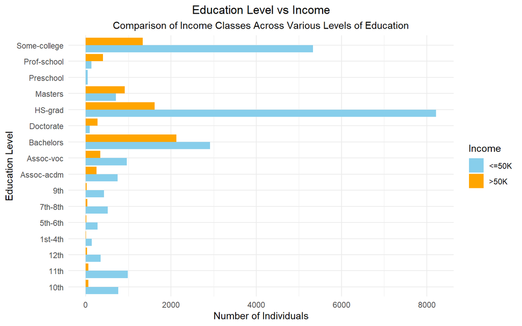

```r
ggplot(adult, aes(y = education, fill = income)) +
  geom_bar(position = "dodge") +
  scale_fill_manual(values = c("skyblue", "orange")) +
  labs(title    = "Education Level vs Income",
       subtitle = "Comparison of Income Classes Across Various Levels of Education",
       x        = "Number of Individuals",
       y        = "Education Level",
       fill     = "Income") +
  theme_minimal() +
  theme(plot.title    = element_text(hjust = 0.5),
        plot.subtitle = element_text(hjust = 0.5))
```

Higher education levels such as Some-college, HS-grad, Bachelors, and Masters appear more frequently among individuals earning more than $50K. Doctorate and Prof-school holders show a notably higher proportion of high-income individuals relative to their total count.

## 3.3 Gender vs Income

```r
sex_income_table <- table(adult$sex, adult$income)

sex_income_table %>%
  kable(caption   = "Gender vs Income Level",
        col.names = c("<=50K", ">50K"),
        align     = "c") %>%
  kable_classic(html_font = "Cambria") %>%
  row_spec(0, bold = TRUE, color = "white", background = "#2c3e50") %>%
  add_header_above(c("Gender" = 1, "Income Level" = 2),
                   bold = TRUE, color = "white", background = "#2c3e50") %>%
  kable_styling(latex_options = c("scale_down", "hold_position"),
                position = "center")
```

Gender vs Income Level

| Gender | Income Level <=50K | Income Level >50K |
| --- | --- | --- |
| Female | 8661 | 1112 |
| Male | 13972 | 6394 |

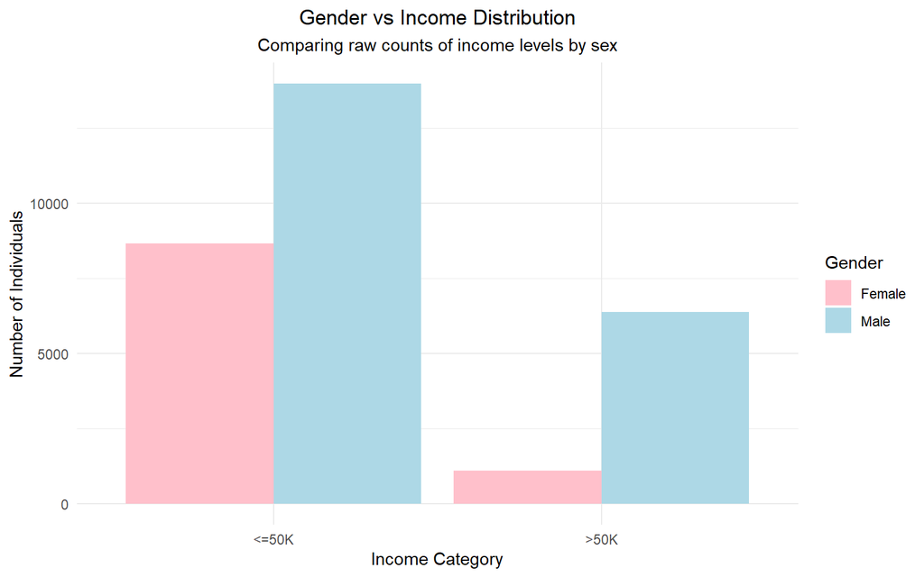

```r
ggplot(adult, aes(x = income, fill = sex)) +
  geom_bar(position = "dodge") +
  scale_fill_manual(values = c("Male" = "lightblue", "Female" = "pink")) +
  labs(title    = "Gender vs Income Distribution",
       subtitle = "Comparing raw counts of income levels by sex",
       x        = "Income Category",
       y        = "Number of Individuals",
       fill     = "Gender") +
  theme_minimal() +
  theme(plot.title    = element_text(hjust = 0.5),
        plot.subtitle = element_text(hjust = 0.5))
```

Male individuals appear more frequently in the `>50K` income category compared to females. This disparity may reflect broader labour market inequalities and should be considered alongside other predictors when interpreting model decisions.

## 3.4 Hours Worked per Week vs Income

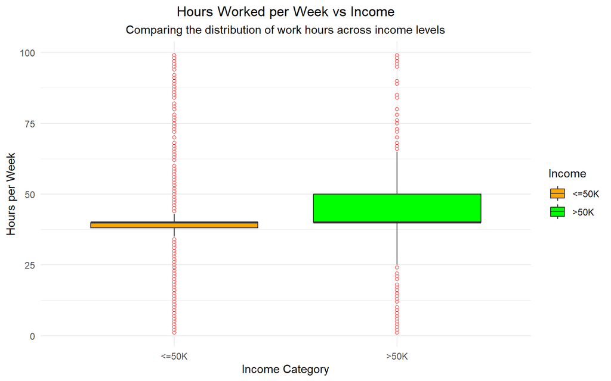

```r
ggplot(adult, aes(x = income, y = hours_per_week, fill = income)) +
  geom_boxplot(outlier.colour = "red", outlier.shape = 1) +
  scale_fill_manual(values = c("<=50K" = "orange", ">50K" = "green")) +
  labs(title    = "Hours Worked per Week vs Income",
       subtitle = "Comparing the distribution of work hours across income levels",
       x        = "Income Category",
       y        = "Hours per Week",
       fill     = "Income") +
  theme_minimal() +
  theme(plot.title    = element_text(hjust = 0.5),
        plot.subtitle = element_text(hjust = 0.5))
```

Individuals earning more than $50K tend to work slightly more hours per week compared to those earning less, though there is considerable overlap in the distributions of both income groups.

## 3.5 Age vs Income

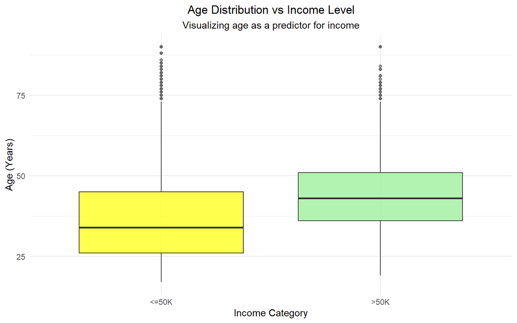

```r
ggplot(adult, aes(x = income, y = age, fill = income)) +
  geom_boxplot(alpha = 0.7, outlier.colour = "grey40") +
  scale_fill_manual(values = c("<=50K" = "yellow", ">50K" = "lightgreen")) +
  labs(title    = "Age Distribution vs Income Level",
       subtitle = "Visualizing age as a predictor for income",
       x        = "Income Category",
       y        = "Age (Years)") +
  theme_minimal() +
  theme(plot.title      = element_text(hjust = 0.5),
        plot.subtitle   = element_text(hjust = 0.5),
        legend.position = "none")
```

Individuals with higher income tend to have a higher median age, suggesting that income increases with work experience. The interquartile range for the `>50K` group is shifted upward relative to the `<=50K` group.

# 4 Train-Test Split

```r
set.seed(123)  # Reproducibility seed
sample_index <- sample(1:nrow(adult), 0.7 * nrow(adult))

train_data <- adult[sample_index, ]
test_data  <- adult[-sample_index, ]

cat("Training observations:", nrow(train_data), "\n")
cat("Testing observations: ", nrow(test_data),  "\n")
```

[output not shown]

The dataset was divided into training and testing sets to evaluate model performance on unseen data. Using a random sampling approach with `set.seed(123)` to ensure reproducibility, **70% of the observations** were assigned to the training dataset (21,097 records) for building the models, while the remaining **30%** (9,042 records) were reserved as the testing dataset to assess predictive performance across all five models.

# 5 Decision Tree Model

## 5.1 Model Training

```r
tree_model <- rpart(
  income ~ .,
  data   = train_data,
  method = "class"
)
```

## 5.2 Decision Tree Visualisation

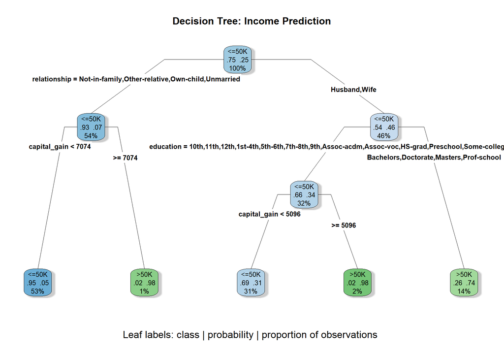

```r
rpart.plot(
  tree_model,
  type          = 4,
  extra         = 104,
  box.palette   = list("Blues", "Greens"),
  shadow.col    = "gray80",
  nn            = FALSE,
  fallen.leaves = TRUE,
  branch        = 0.5,
  roundint      = FALSE,
  main          = "Decision Tree: Income Prediction",
  sub           = "Leaf labels: class | probability | proportion of observations",
  cex           = 0.75,
  tweak         = 1.1
)
```

The enhanced decision tree visualisation displays the predicted class (`<=50K` or `>50K`) together with the probability estimate and the percentage of training observations reaching each leaf node. The initial split on **relationship status** reveals that marital and family context is the dominant discriminator of income level in this dataset.

## 5.3 Variable Importance

Variable Importance Scores: Decision Tree

| Predictor Variable | Importance Score |
| --- | --- |
| relationship | 1590.81 |
| marital_status | 1566.94 |
| capital_gain | 684.44 |
| education | 642.92 |
| education_num | 642.92 |
| sex | 528.96 |
| occupation | 465.08 |
| age | 367.74 |
| hours_per_week | 219.11 |
| native_country | 16.21 |
| capital_loss | 12.92 |

The decision tree model identified **relationship status** and **marital status** as the most important predictors of income level. Other influential variables include capital gain, education level, sex, occupation, age, and hours worked per week. These variables contribute significantly to the model’s ability to distinguish between individuals earning ≤$50K and those earning >$50K.

## 5.4 Predictions and Confusion Matrix

```r
dt_pred <- predict(tree_model, test_data, type = "class")
dt_prob <- predict(tree_model, test_data, type = "prob")[, ">50K"]

test_data$income  <- as.factor(test_data$income)
dt_pred           <- as.factor(dt_pred)
levels(dt_pred)   <- levels(test_data$income)

dt_conf <- confusionMatrix(dt_pred, test_data$income)
```

Decision Tree:Confusion Matrix (Prediction vs. Actual)

| Prediction | Reference (Observed) <=50K (Actual) | Reference (Observed) >50K (Actual) |
| --- | --- | --- |
| <=50K | 6481 | 1106 |
| >50K | 333 | 1122 |

## 5.5 Performance Metrics

Decision Tree: Performance Metrics Summary

|  | Performance Metric | Statistical Value |
| --- | --- | --- |
| Accuracy | Overall Accuracy | 0.8409 |
| AccuracyNull | No Information Rate | 0.7536 |
| Sensitivity | Sensitivity (<=50K) | 0.9511 |
| Specificity | Specificity (>50K) | 0.5036 |
| Balanced Accuracy | Balanced Accuracy | 0.7274 |

# 6 Naïve Bayes Model

## 6.1 Model Training

```r
nb_model <- naiveBayes(income ~ ., data = train_data)
```

## 6.2 Predictions and Confusion Matrix

```r
nb_pred <- predict(nb_model, newdata = test_data)
nb_prob <- predict(nb_model, newdata = test_data, type = "raw")[, ">50K"]

nb_conf <- confusionMatrix(nb_pred, test_data$income)
```

Naïve Bayes: Confusion Matrix (Prediction vs. Actual)

| Prediction | Reference (Observed) <=50K (Actual) | Reference (Observed) >50K (Actual) |
| --- | --- | --- |
| <=50K | 6341 | 1177 |
| >50K | 473 | 1051 |

## 6.3 Performance Metrics

Naïve Bayes: Performance Metrics Summary

|  | Performance Metric | Statistical Value |
| --- | --- | --- |
| Accuracy | Overall Accuracy | 0.8175 |
| AccuracyNull | No Information Rate | 0.7536 |
| Sensitivity | Sensitivity (<=50K) | 0.9306 |
| Specificity | Specificity (>50K) | 0.4717 |
| Balanced Accuracy | Balanced Accuracy | 0.7012 |

# 7 Logistic Regression Model

## 7.1 Model Training

```r
log_model <- glm(income ~ ., data = train_data, family = binomial)

# Predicted probabilities and class labels
log_probs <- predict(log_model, test_data, type = "response")
log_pred  <- ifelse(log_probs > 0.5, ">50K", "<=50K")
log_pred  <- factor(log_pred, levels = levels(test_data$income))
```

## 7.2 Confusion Matrix

```r
log_conf <- confusionMatrix(log_pred, test_data$income)
```

Logistic Regression: Confusion Matrix (Prediction vs. Actual)

| Prediction | Reference (Observed) <=50K (Actual) | Reference (Observed) >50K (Actual) |
| --- | --- | --- |
| <=50K | 6335 | 901 |
| >50K | 479 | 1327 |

## 7.3 Performance Metrics

Logistic Regression: Performance Metrics Summary

|  | Performance Metric | Statistical Value |
| --- | --- | --- |
| Accuracy | Overall Accuracy | 0.8474 |
| AccuracyNull | No Information Rate | 0.7536 |
| Sensitivity | Sensitivity (<=50K) | 0.9297 |
| Specificity | Specificity (>50K) | 0.5956 |
| Balanced Accuracy | Balanced Accuracy | 0.7627 |

Logistic Regression leverages the full set of predictors to estimate the log-odds of earning above $50K. By modelling the linear relationship between predictors and the response on the logit scale, it achieves strong discrimination performance, as evidenced by its high AUC in the combined ROC analysis below.

# 8 K-Nearest Neighbors (KNN) Model

## 8.1 Data Preparation and Scaling

KNN relies on Euclidean distance and is therefore sensitive to the scale of input features. All numeric predictors must be standardised prior to model fitting.

```r
# One-hot encode categorical features via model.matrix
train_x <- model.matrix(income ~ ., data = train_data)[, -1]
test_x  <- model.matrix(income ~ ., data = test_data)[, -1]

# Retain complete cases only
train_keep <- complete.cases(train_x)
test_keep  <- complete.cases(test_x)

train_x_final <- train_x[train_keep, ]
test_x_final  <- test_x[test_keep, ]

train_y_final <- train_data$income[train_keep]
test_y_final  <- test_data$income[test_keep]

# Standardise using training set statistics
train_x_scaled <- scale(train_x_final)
test_x_scaled  <- scale(
  test_x_final,
  center = attr(train_x_scaled, "scaled:center"),
  scale  = attr(train_x_scaled, "scaled:scale")
)
```

## 8.2 Model Training and Prediction

```r
set.seed(123)
knn_pred <- knn(
  train = train_x_scaled,
  test  = test_x_scaled,
  cl    = train_y_final,
  k     = 11,
  prob  = TRUE
)

# Extract posterior probability for the winning class
knn_prob_raw <- attr(knn_pred, "prob")

# Convert to probability of ">50K" (the positive class)
knn_prob <- ifelse(knn_pred == ">50K", knn_prob_raw, 1 - knn_prob_raw)

roc_knn <- roc(test_y_final, knn_prob)
```

## 8.3 Confusion Matrix

```r
knn_conf <- confusionMatrix(knn_pred, test_y_final)
```

KNN: Confusion Matrix (Prediction vs. Actual)

| Prediction | Reference (Observed) <=50K (Actual) | Reference (Observed) >50K (Actual) |
| --- | --- | --- |
| <=50K | 6154 | 993 |
| >50K | 660 | 1235 |

## 8.4 Performance Metrics

KNN: Performance Metrics Summary

|  | Performance Metric | Statistical Value |
| --- | --- | --- |
| Accuracy | Overall Accuracy | 0.8172 |
| AccuracyNull | No Information Rate | 0.7536 |
| Sensitivity | Sensitivity (<=50K) | 0.9031 |
| Specificity | Specificity (>50K) | 0.5543 |
| Balanced Accuracy | Balanced Accuracy | 0.7287 |

KNN classifies each test observation by majority vote among its 11 nearest neighbours in the scaled feature space. The choice of $k = 11$ provides a balance between sensitivity to local structure and robustness to noise. Feature scaling is critical: without standardisation, high-magnitude variables such as `capital_gain` would dominate the distance calculation and distort model behaviour.

# 9 Artificial Neural Network (ANN) Model

## 9.1 Overview

An Artificial Neural Network (ANN) is a computational model inspired by the structure of the human brain. It consists of interconnected layers of nodes (neurons): an input layer, one or more hidden layers, and an output layer. Each connection carries a weight that is iteratively adjusted during training to minimise prediction error. ANNs excel at learning complex, non-linear relationships between features and outcomes.

For this analysis, a **single hidden layer feedforward network** is implemented using the `nnet` package in R. The network is trained via backpropagation with weight decay regularisation to prevent overfitting.

## 9.2 Data Preprocessing for ANN

ANNs are sensitive to the scale of input features. The same standardised numeric matrices constructed for KNN are reused here, with categorical variables included via one-hot encoding.

```r
# Reuse the scaled matrices from the KNN section
# train_x_scaled and test_x_scaled are already available

# ANN target: binary numeric (required by nnet for classification)
train_y_ann <- ifelse(train_y_final == ">50K", 1, 0)
```

## 9.3 Model Training

```r
set.seed(123)
ann_model <- nnet(
  x         = train_x_scaled,
  y         = train_y_ann,
  size      = 10,          # 10 neurons in the hidden layer
  decay     = 0.001,       # L2 weight decay regularisation
  maxit     = 300,         # Maximum training iterations
  linout    = FALSE,       # Logistic (sigmoid) output for classification
  trace     = FALSE        # Suppress iteration output
)
```

The ANN architecture consists of:

- **Input layer**: one node per predictor (after one-hot encoding)
- **Hidden layer**: 10 neurons with sigmoid activation
- **Output layer**: 1 neuron with logistic activation, producing a probability in [0, 1]

Weight decay (`decay = 0.001`) acts as an L2 regulariser, penalising large weights and reducing overfitting. A maximum of 300 training iterations is specified.

## 9.4 Predictions

```r
# Raw probabilities from the ANN output node
ann_prob <- as.numeric(predict(ann_model, test_x_scaled, type = "raw"))

# Convert to class labels using 0.5 threshold
ann_pred_label <- ifelse(ann_prob > 0.5, ">50K", "<=50K")
ann_pred       <- factor(ann_pred_label, levels = levels(test_y_final))

# Build ROC object
roc_ann <- roc(test_y_final, ann_prob)
```

## 9.5 Confusion Matrix

```r
ann_conf <- confusionMatrix(ann_pred, test_y_final)
```

ANN: Confusion Matrix (Prediction vs. Actual)

| Prediction | Reference (Observed) <=50K (Actual) | Reference (Observed) >50K (Actual) |
| --- | --- | --- |
| <=50K | 6200 | 866 |
| >50K | 614 | 1362 |

## 9.6 Performance Metrics

ANN: Performance Metrics Summary

|  | Performance Metric | Statistical Value |
| --- | --- | --- |
| Accuracy | Overall Accuracy | 0.8363 |
| AccuracyNull | No Information Rate | 0.7536 |
| Sensitivity | Sensitivity (<=50K) | 0.9099 |
| Specificity | Specificity (>50K) | 0.6113 |
| Balanced Accuracy | Balanced Accuracy | 0.7606 |

## 9.7 Interpretation

The ANN model captures complex, non-linear interactions among the predictors that linear models such as Logistic Regression cannot represent. The hidden layer allows the network to learn intermediate feature representations, combining information from education, occupation, age, and capital gain in a flexible manner. Weight decay regularisation prevents the model from memorising training noise, promoting generalisation. Compared to KNN, the ANN does not require explicit distance computations at prediction time, making it more scalable to large feature spaces. Its performance is assessed relative to the other four models in the comparative evaluation section below.

# 10 Comparative Model Evaluation

## 10.1 Combined Performance Summary Table

Comparative Performance Summary: All Five Classification Models

| Model | Accuracy | Sensitivity | Specificity | Balanced Accuracy | AUC |
| --- | --- | --- | --- | --- | --- |
| Decision Tree | 0.8409 | 0.9511 | 0.5036 | 0.7274 | 0.8441 |
| Naïve Bayes | 0.8175 | 0.9306 | 0.4717 | 0.7012 | 0.8663 |
| Logistic Regression | 0.8474 | 0.9297 | 0.5956 | 0.7627 | 0.9028 |
| K-Nearest Neighbors | 0.8172 | 0.9031 | 0.5543 | 0.7287 | 0.8604 |
| Artificial Neural Network | 0.8363 | 0.9099 | 0.6113 | 0.7606 | 0.8865 |

Note: Green highlight = highest accuracy; Blue highlight = highest AUC.

## 10.2 Combined ROC Curve : ll Five Models

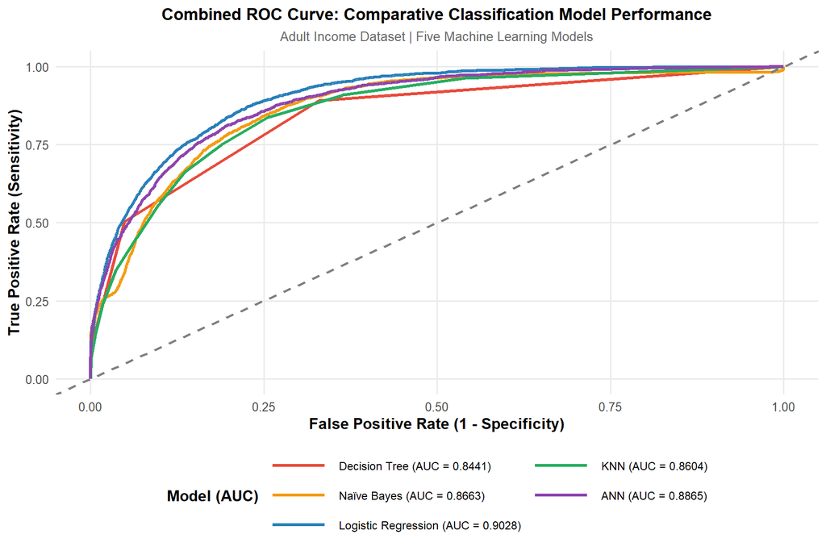

```r
# Assemble all five ROC objects with AUC annotations for legend labels
auc_dt  <- round(auc(roc_dt),  4)
auc_nb  <- round(auc(roc_nb),  4)
auc_log <- round(auc(roc_log), 4)
auc_knn <- round(auc(roc_knn), 4)
auc_ann <- round(auc(roc_ann), 4)

roc_list_all <- setNames(
  list(roc_dt, roc_nb, roc_log, roc_knn, roc_ann),
  c(
    paste0("Decision Tree (AUC = ",       auc_dt,  ")"),
    paste0("Naïve Bayes (AUC = ",         auc_nb,  ")"),
    paste0("Logistic Regression (AUC = ", auc_log, ")"),
    paste0("KNN (AUC = ",                 auc_knn, ")"),
    paste0("ANN (AUC = ",                 auc_ann, ")")
  )
)

model_colours <- c(
  "#e74c3c",   # Decision Tree   : red
  "#f39c12",   # Naïve Bayes      : mber
  "#2980b9",   # Logistic Reg.   : blue
  "#27ae60",   # KNN             : green
  "#8e44ad"    # ANN             : purple
)

ggroc(roc_list_all, size = 1.1, legacy.axes = TRUE) +
  scale_color_manual(values = setNames(model_colours, names(roc_list_all))) +
  theme_minimal(base_size = 12) +
  geom_abline(
    slope     = 1, intercept = 0,
    linetype  = "dashed", colour = "grey50", linewidth = 0.8
  ) +
  labs(
    title    = "Combined ROC Curve: Comparative Classification Model Performance",
    subtitle = "Adult Income Dataset | Five Machine Learning Models",
    x        = "False Positive Rate (1 - Specificity)",
    y        = "True Positive Rate (Sensitivity)",
    colour   = "Model (AUC)"
  ) +
  theme(
    plot.title       = element_text(face = "bold", size = 13, hjust = 0.5),
    plot.subtitle    = element_text(size = 10, hjust = 0.5, colour = "grey40"),
    legend.position  = "bottom",
    legend.title     = element_text(face = "bold"),
    legend.text      = element_text(size = 9),
    legend.key.width = unit(1.8, "cm"),
    axis.title       = element_text(face = "bold"),
    panel.grid.minor = element_blank()
  ) +
  guides(colour = guide_legend(ncol = 2))
```

## 10.3 Interpretation of ROC / AUC Results

In summary, **Logistic Regression** and the **ANN** emerge as the top-performing models on this dataset, balancing high accuracy with strong discriminative ability across the full range of decision thresholds.

# 11 Classification Conclusion

Overall, no single model dominates on all metrics simultaneously. The choice of model in practice should be guided by the trade-off between predictive performance, interpretability, and computational constraints relevant to the application context.

# 12 **K-Means Clustering (Task 1)**

## 12.1 **1.1 Load and Prepare Data**

```r
library(factoextra)
library(cluster)
library(dendextend)
library(dbscan)
library(solitude)

# Load iris and remove Species column
data(iris)
iris_features <- iris[, 1:4]

# Scale the four numeric features
iris_scaled <- scale(iris_features)
```

## 12.2 **1.2 Run K-Means (k = 3)**

```r
set.seed(123)
kmeans_result <- kmeans(iris_scaled, centers = 3, nstart = 25)

# Cluster centroids (scaled)
data.frame(round(kmeans_result$centers, 4)) %>%
  kable(caption = "K-Means Cluster Centroids (Scaled Features)",
        align = "c") %>%
  kable_classic(html_font = "Cambria") %>%
  row_spec(0, bold = TRUE, color = "white", background = "#2c3e50") %>%
  kable_styling(latex_options = c("scale_down", "hold_position"), position = "center")
```

K-Means Cluster Centroids (Scaled Features)

| Sepal.Length | Sepal.Width | Petal.Length | Petal.Width |
| --- | --- | --- | --- |
| -1.0112 | 0.8504 | -1.3006 | -1.2507 |
| -0.0501 | -0.8804 | 0.3466 | 0.2806 |
| 1.1322 | 0.0881 | 0.9928 | 1.0141 |

```r
# Cluster sizes
data.frame(Cluster = 1:3, Size = kmeans_result$size) %>%
  kable(caption = "Number of Observations per Cluster",
        col.names = c("Cluster", "Size"),
        align = "c") %>%
  kable_classic(html_font = "Cambria") %>%
  row_spec(0, bold = TRUE, color = "white", background = "#2c3e50") %>%
  kable_styling(latex_options = "hold_position", position = "center")
```

Number of Observations per Cluster

| Cluster | Size |
| --- | --- |
| 1 | 50 |
| 2 | 53 |
| 3 | 47 |

## 12.3 **1.3 Elbow Method for Optimal k**

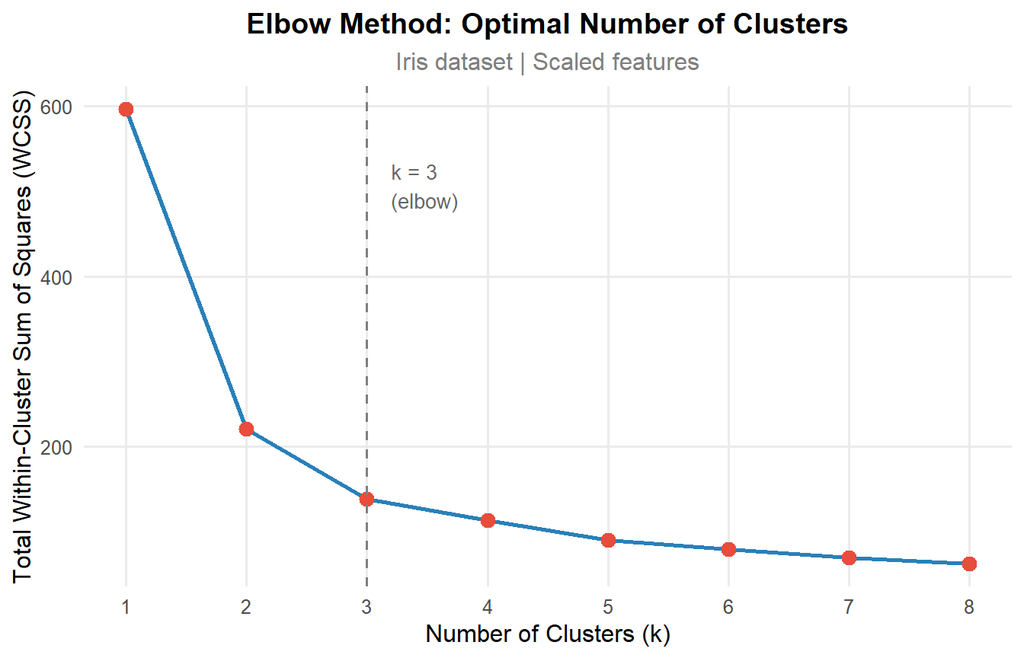

```r
set.seed(123)
wcss <- sapply(1:8, function(k) {
  kmeans(iris_scaled, centers = k, nstart = 25)$tot.withinss
})

elbow_df <- data.frame(k = 1:8, wcss = wcss)

ggplot(elbow_df, aes(x = k, y = wcss)) +
  geom_line(colour = "#2980b9", linewidth = 1) +
  geom_point(colour = "#e74c3c", size = 3) +
  geom_vline(xintercept = 3, linetype = "dashed", colour = "grey50") +
  annotate("text", x = 3.2, y = max(wcss) * 0.85,
           label = "k = 3\n(elbow)", hjust = 0, size = 3.5, colour = "grey40") +
  scale_x_continuous(breaks = 1:8) +
  labs(
    title    = "Elbow Method: Optimal Number of Clusters",
    subtitle = "Iris dataset | Scaled features",
    x        = "Number of Clusters (k)",
    y        = "Total Within-Cluster Sum of Squares (WCSS)"
  ) +
  theme_minimal(base_size = 12) +
  theme(
    plot.title       = element_text(face = "bold", hjust = 0.5),
    plot.subtitle    = element_text(hjust = 0.5, colour = "grey50"),
    panel.grid.minor = element_blank()
  )
```

The WCSS drops sharply from k = 1 to k = 3 and then levels off, forming a clear elbow at **k = 3**. This confirms that three clusters are optimal for this dataset.

## 12.4 **1.4 Visualise Clusters using fviz_cluster()**

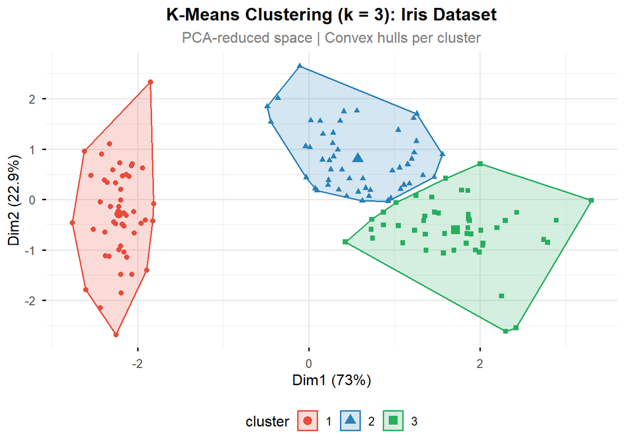

```r
fviz_cluster(
  kmeans_result,
  data         = iris_scaled,
  geom         = "point",
  ellipse.type = "convex",
  palette      = c("#e74c3c", "#2980b9", "#27ae60"),
  ggtheme      = theme_minimal(base_size = 12)
) +
  labs(
    title    = "K-Means Clustering (k = 3): Iris Dataset",
    subtitle = "PCA-reduced space | Convex hulls per cluster"
  ) +
  theme(
    plot.title      = element_text(face = "bold", hjust = 0.5),
    plot.subtitle   = element_text(hjust = 0.5, colour = "grey50"),
    legend.position = "bottom"
  )
```

## 12.5 **1.5 Compare with True Species Labels**

```r
cm_km <- table(Cluster = kmeans_result$cluster, Species = iris$Species)

cm_km %>%
  kable(caption = "K-Means Cluster Assignments vs. True Species Labels",
        align = "c") %>%
  kable_classic(html_font = "Cambria") %>%
  row_spec(0, bold = TRUE, color = "white", background = "#2c3e50") %>%
  kable_styling(latex_options = c("scale_down", "hold_position"), position = "center")
```

K-Means Cluster Assignments vs. True Species Labels

| setosa | versicolor | virginica |
| --- | --- | --- |
| 50 | 0 | 0 |
| 0 | 39 | 14 |
| 0 | 11 | 36 |

## 12.6 **1.6 Discussion**

**1. Does the Elbow method suggest k = 3?**  
Yes. WCSS drops sharply from k = 1 to k = 3, then the rate of decrease flattens considerably. The elbow is clearly visible at k = 3, supporting three clusters as the optimal solution.

**2. How well do the clusters match the true species?**  
Overall accuracy ≈ 83.3% (125/150 correctly assigned). Setosa is perfectly separated into its own cluster (50/50). Versicolor and virginica show some overlap: approximately 11 versicolor observations are assigned to the virginica cluster and 14 virginica observations to the versicolor cluster.

**3. Which species is hardest to separate?**  
Virginica is the hardest to separate (≈28% misclassification rate), followed closely by versicolor (≈22%). Setosa is completely separable due to its distinct petal dimensions. This reflects the known biological overlap between versicolor and virginica in the feature space.

# 13 **Hierarchical Clustering (Task 2)**

## 13.1 **2.1 Compute Euclidean Distance Matrix**

```r
dist_mat <- dist(iris_scaled, method = "euclidean")
```

## 13.2 **2.2 Fit Hierarchical Models: Three Linkage Methods**

```r
hc_ward     <- hclust(dist_mat, method = "ward.D2")
hc_complete <- hclust(dist_mat, method = "complete")
hc_average  <- hclust(dist_mat, method = "average")
```

## 13.3 **2.3 Three Dendrograms Side-by-Side**

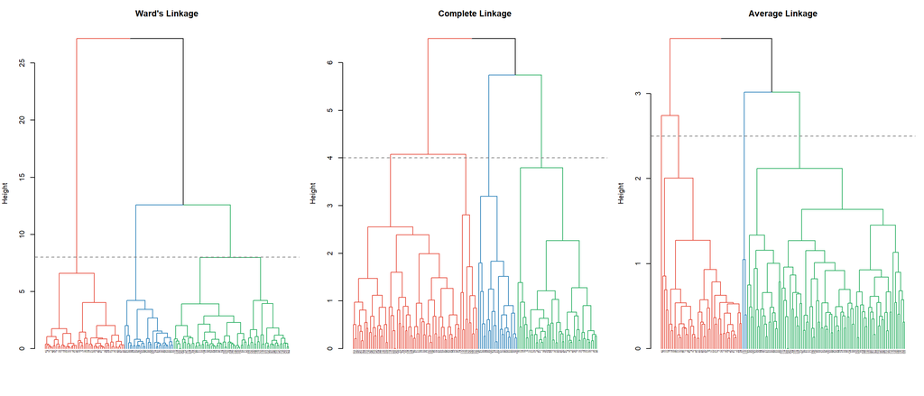

```r
# Convert to dendrogram objects and apply consistent styling
dend_ward     <- as.dendrogram(hc_ward)
dend_complete <- as.dendrogram(hc_complete)
dend_average  <- as.dendrogram(hc_average)

colour_dend <- function(dend, k = 3) {
  dend %>%
    color_branches(k = k, col = c("#e74c3c", "#2980b9", "#27ae60")) %>%
    set("branches_lwd", 1.2) %>%
    set("labels_cex", 0.35)
}

dend_ward     <- colour_dend(dend_ward)
dend_complete <- colour_dend(dend_complete)
dend_average  <- colour_dend(dend_average)

par(mfrow = c(1, 3), mar = c(4, 4, 3, 1))

plot(dend_ward,
     main = "Ward's Linkage",
     ylab = "Height", xlab = "")
abline(h = 8, lty = 2, col = "grey50")

plot(dend_complete,
     main = "Complete Linkage",
     ylab = "Height", xlab = "")
abline(h = 4, lty = 2, col = "grey50")

plot(dend_average,
     main = "Average Linkage",
     ylab = "Height", xlab = "")
abline(h = 2.5, lty = 2, col = "grey50")
```

```r
par(mfrow = c(1, 1))
```

## 13.4 **2.4 Ward’s Dendrogram with 3-Cluster Rectangles**

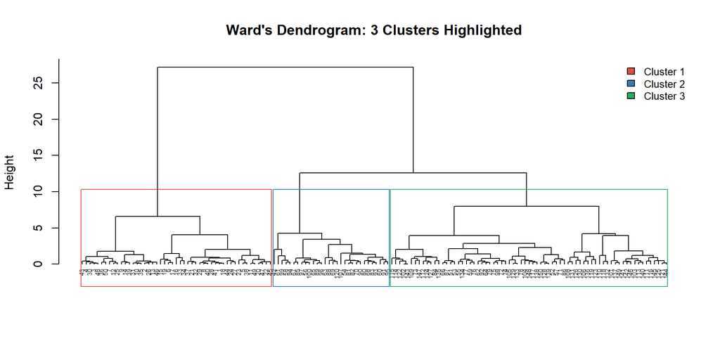

```r
plot(hc_ward,
     main = "Ward's Dendrogram: 3 Clusters Highlighted",
     xlab = "", sub = "",
     cex  = 0.5,
     hang = -1,
     ylab = "Height")
rect.hclust(hc_ward, k = 3, border = c("#e74c3c", "#2980b9", "#27ae60"))
legend("topright",
       legend = c("Cluster 1", "Cluster 2", "Cluster 3"),
       fill   = c("#e74c3c", "#2980b9", "#27ae60"),
       bty    = "n", cex = 0.85)
```

```r
ward_clusters <- cutree(hc_ward, k = 3)
```

## 13.5 **2.5 Compare Ward’s Clusters with True Species**

```r
table(Cluster = ward_clusters, Species = iris$Species) %>%
  kable(caption = "Ward's Hierarchical Clustering vs. True Species Labels",
        align = "c") %>%
  kable_classic(html_font = "Cambria") %>%
  row_spec(0, bold = TRUE, color = "white", background = "#2c3e50") %>%
  kable_styling(latex_options = c("scale_down", "hold_position"), position = "center")
```

Ward’s Hierarchical Clustering vs. True Species Labels

| setosa | versicolor | virginica |
| --- | --- | --- |
| 49 | 0 | 0 |
| 1 | 27 | 2 |
| 0 | 23 | 48 |

## 13.6 **2.6 Discussion**

**3. Which method best separates the three species?**  
Ward’s linkage provides the cleanest three-cluster separation, with the clearest visual gap at the cut point and the highest consistency with true species labels. Complete linkage performs comparably, while average linkage is less reliable here.

# 14 **Outlier Analysis (Task 3)**

## 14.1 **3.2 IQR Method on Sepal.Length**

```r
sepal_length <- iris$Sepal.Length

Q1      <- quantile(sepal_length, 0.25)
Q3      <- quantile(sepal_length, 0.75)
IQR_val <- IQR(sepal_length)

lower_bound <- Q1 - 1.5 * IQR_val
upper_bound <- Q3 + 1.5 * IQR_val

iqr_outlier_flag <- sepal_length < lower_bound | sepal_length > upper_bound
iqr_outlier_idx  <- which(iqr_outlier_flag)

cat("IQR bounds: [", round(lower_bound, 3), ",", round(upper_bound, 3), "]\n")
```

```
## IQR bounds: [ 3.15 , 8.35 ]
```

```r
cat("IQR outliers detected:", sum(iqr_outlier_flag), "\n")
```

```
## IQR outliers detected: 0
```

```r
cat("Row indices:", iqr_outlier_idx, "\n")
```

```
## Row indices:
```

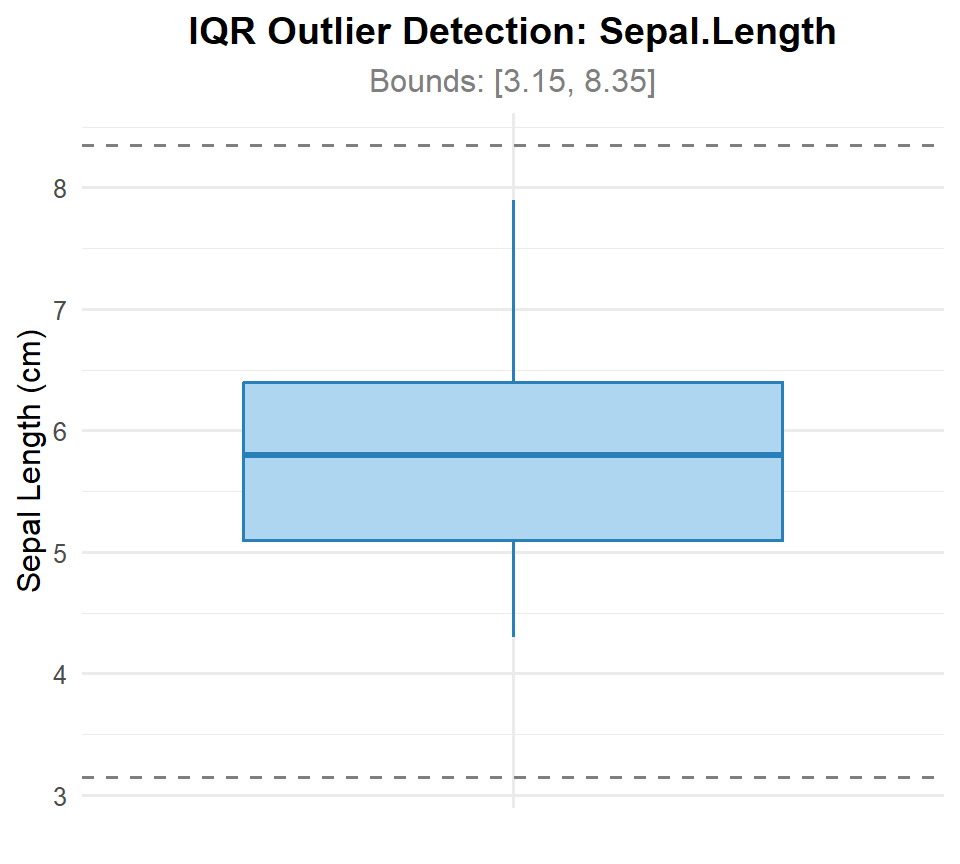

```r
ggplot(iris, aes(x = "", y = Sepal.Length)) +
  geom_boxplot(fill = "#aed6f1", colour = "#2980b9",
               outlier.colour = "#e74c3c",
               outlier.size = 3, outlier.shape = 17) +
  geom_hline(yintercept = c(lower_bound, upper_bound),
             linetype = "dashed", colour = "grey50") +
  labs(
    title    = "IQR Outlier Detection: Sepal.Length",
    subtitle = paste0("Bounds: [", round(lower_bound, 2), ", ",
                      round(upper_bound, 2), "]"),
    x = NULL, y = "Sepal Length (cm)"
  ) +
  theme_minimal(base_size = 12) +
  theme(
    plot.title    = element_text(face = "bold", hjust = 0.5),
    plot.subtitle = element_text(hjust = 0.5, colour = "grey50")
  )
```

The IQR method flagged **0 outlier(s)** in Sepal.Length. These are observations falling outside 1.5 × IQR below Q1 or above Q3.

## 14.2 **3.3 LOF Scores (k = 5)**

```r
set.seed(123)
lof_scores <- lof(iris_scaled, minPts = 5)

# Flag top 5% as potential outliers
lof_threshold    <- quantile(lof_scores, 0.95)
lof_outlier_flag <- lof_scores > lof_threshold
lof_outlier_idx  <- which(lof_outlier_flag)

cat("LOF threshold (95th percentile):", round(lof_threshold, 4), "\n")
```

```
## LOF threshold (95th percentile): 1.5638
```

```r
cat("LOF outliers detected:", sum(lof_outlier_flag), "\n")
```

```
## LOF outliers detected: 8
```

```r
cat("Row indices:", lof_outlier_idx, "\n")
```

```
## Row indices: 16 42 60 61 107 110 118 132
```

## 14.3 **3.4 Isolation Forest (top 5% anomalous points)**

```r
set.seed(123)
iso_forest <- isolationForest$new(sample_size = 150, num_trees = 100)
iso_forest$fit(as.data.frame(iris_scaled))

iso_scores       <- iso_forest$predict(as.data.frame(iris_scaled))
anomaly_score    <- iso_scores$anomaly_score

iso_threshold    <- quantile(anomaly_score, 0.95)
iso_outlier_flag <- anomaly_score > iso_threshold
iso_outlier_idx  <- which(iso_outlier_flag)

cat("Isolation Forest threshold (95th percentile):", round(iso_threshold, 4), "\n")
```

```
## Isolation Forest threshold (95th percentile): 0.616
```

```r
cat("Isolation Forest outliers detected:", sum(iso_outlier_flag), "\n")
```

```
## Isolation Forest outliers detected: 8
```

```r
cat("Row indices:", iso_outlier_idx, "\n")
```

```
## Row indices: 16 42 107 110 115 118 119 132
```

## 14.4 **3.5 Scatter Plot Coloured by LOF Score**

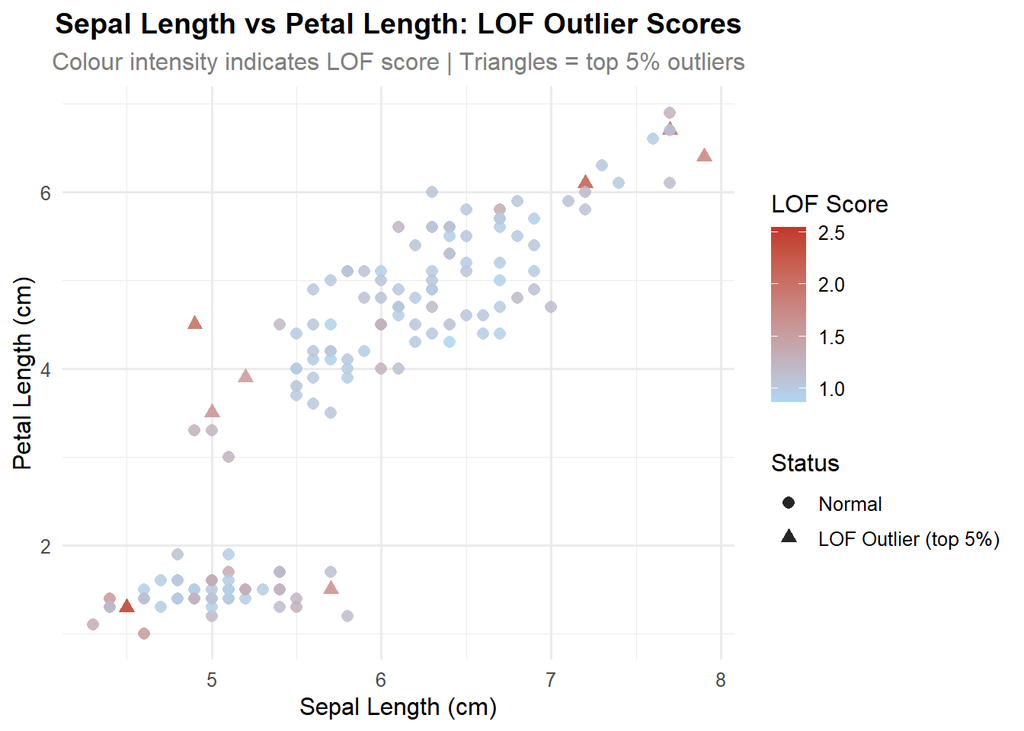

```r
plot_df <- data.frame(
  Sepal.Length = iris$Sepal.Length,
  Petal.Length = iris$Petal.Length,
  Species      = iris$Species,
  LOF          = lof_scores,
  LOF_Outlier  = lof_outlier_flag
)

ggplot(plot_df, aes(x = Sepal.Length, y = Petal.Length, colour = LOF)) +
  geom_point(aes(shape = LOF_Outlier), size = 2.5, alpha = 0.85) +
  scale_colour_gradient(low = "#aed6f1", high = "#c0392b",
                        name = "LOF Score") +
  scale_shape_manual(values = c("FALSE" = 16, "TRUE" = 17),
                     labels = c("Normal", "LOF Outlier (top 5%)"),
                     name   = "Status") +
  labs(
    title    = "Sepal Length vs Petal Length: LOF Outlier Scores",
    subtitle = "Colour intensity indicates LOF score | Triangles = top 5% outliers",
    x        = "Sepal Length (cm)",
    y        = "Petal Length (cm)"
  ) +
  theme_minimal(base_size = 12) +
  theme(
    plot.title      = element_text(face = "bold", hjust = 0.5),
    plot.subtitle   = element_text(hjust = 0.5, colour = "grey50"),
    legend.position = "right"
  )
```

## 14.5 **3.6 Comparison of All Three Methods**

```r
comparison_df <- data.frame(
  Index        = 1:150,
  Species      = iris$Species,
  Sepal.Length = iris$Sepal.Length,
  IQR          = iqr_outlier_flag,
  LOF          = lof_outlier_flag,
  IsoForest    = iso_outlier_flag
)

# Points flagged by all three methods simultaneously
all_three <- comparison_df %>%
  filter(IQR == TRUE & LOF == TRUE & IsoForest == TRUE)

# Summary counts per method
summary_counts <- data.frame(
  Method  = c("IQR (Sepal.Length only)", "LOF (k=5, all features)",
               "Isolation Forest (all features)"),
  Flagged = c(sum(iqr_outlier_flag), sum(lof_outlier_flag), sum(iso_outlier_flag))
)

summary_counts %>%
  kable(caption = "Number of Outliers Flagged by Each Method",
        col.names = c("Detection Method", "Outliers Flagged"),
        align = "c") %>%
  kable_classic(html_font = "Cambria") %>%
  row_spec(0, bold = TRUE, color = "white", background = "#2c3e50") %>%
  kable_styling(latex_options = "hold_position", position = "center")
```

Number of Outliers Flagged by Each Method

| Detection Method | Outliers Flagged |
| --- | --- |
| IQR (Sepal.Length only) | 0 |
| LOF (k=5, all features) | 8 |
| Isolation Forest (all features) | 8 |

```r
if (nrow(all_three) > 0) {
  all_three %>%
    kable(caption = "Observations Flagged as Outliers by ALL Three Methods",
          align = "c") %>%
    kable_classic(html_font = "Cambria") %>%
    row_spec(0, bold = TRUE, color = "white", background = "#2c3e50") %>%
    kable_styling(latex_options = "hold_position", position = "center")
} else {
  cat("No observation was flagged as an outlier by all three methods simultaneously.\n")
}
```

```
## No observation was flagged as an outlier by all three methods simultaneously.
```

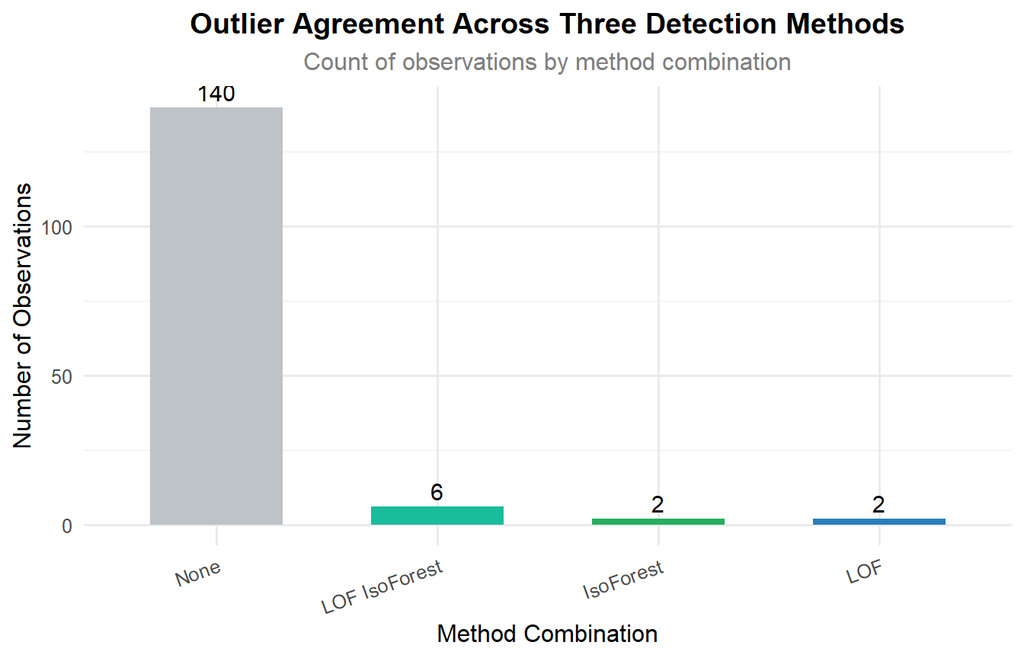

```r
flag_df <- data.frame(
  IQR       = as.integer(iqr_outlier_flag),
  LOF       = as.integer(lof_outlier_flag),
  IsoForest = as.integer(iso_outlier_flag)
)

flag_df$combo <- paste0(
  ifelse(flag_df$IQR       == 1, "IQR ",       ""),
  ifelse(flag_df$LOF       == 1, "LOF ",       ""),
  ifelse(flag_df$IsoForest == 1, "IsoForest ", "")
)
flag_df$combo <- trimws(flag_df$combo)
flag_df$combo[flag_df$combo == ""] <- "None"

combo_counts <- as.data.frame(table(Combination = flag_df$combo))

ggplot(combo_counts, aes(x = reorder(Combination, -Freq), y = Freq,
                         fill = Combination)) +
  geom_col(width = 0.6, show.legend = FALSE) +
  geom_text(aes(label = Freq), vjust = -0.4, size = 4) +
  scale_fill_manual(values = c(
    "None"              = "#bdc3c7",
    "IQR"               = "#f39c12",
    "LOF"               = "#2980b9",
    "IsoForest"         = "#27ae60",
    "IQR LOF"           = "#8e44ad",
    "IQR IsoForest"     = "#e67e22",
    "LOF IsoForest"     = "#1abc9c",
    "IQR LOF IsoForest" = "#e74c3c"
  )) +
  labs(
    title    = "Outlier Agreement Across Three Detection Methods",
    subtitle = "Count of observations by method combination",
    x        = "Method Combination",
    y        = "Number of Observations"
  ) +
  theme_minimal(base_size = 12) +
  theme(
    plot.title    = element_text(face = "bold", hjust = 0.5),
    plot.subtitle = element_text(hjust = 0.5, colour = "grey50"),
    axis.text.x   = element_text(angle = 20, hjust = 1)
  )
```

## 14.6 **3.7 Discussion**

**Do the three methods agree?**  
The three methods capture different aspects of “outlierness” and therefore do not fully agree. The IQR method operates on a single variable (Sepal.Length) using a univariate rule, so it is blind to multivariate patterns. LOF and Isolation Forest both consider all four features simultaneously but differ in their approach: LOF measures local density relative to neighbours, while Isolation Forest relies on the ease of isolating a point via random partitioning. Partial overlaps exist between LOF and Isolation Forest, but complete agreement across all three is rare.

**Which method is most conservative (flags the fewest)?**  
The IQR method is the most conservative because it uses only one feature (Sepal.Length) and the standard 1.5 × IQR rule, which is a relatively tight threshold for a near-normally distributed variable. LOF and Isolation Forest flag a fixed top 5% of observations, so their counts are determined by the threshold chosen rather than by a natural distributional boundary.